## LinkedIn Analytics Report

##### 14 posts: Feb 09, ’24 - Mar 25, ’24

##### The engagement formula is:

$\large Engagement =\huge \frac{{n_{reactions} + (n_{comments} \times 2)}}{n_{views}}$

(Engagement is rated as a percentage of total views, and comments are weighted twice as heavily as reactions.)

#### Subject - Engagement

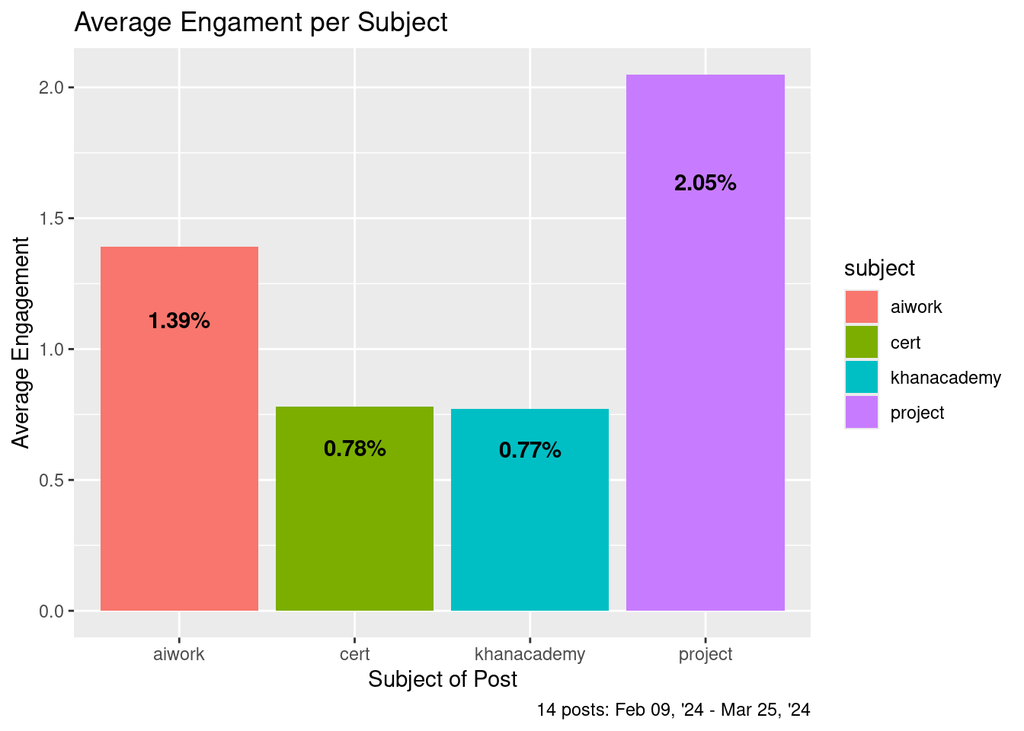

#### Engagement Time-Series

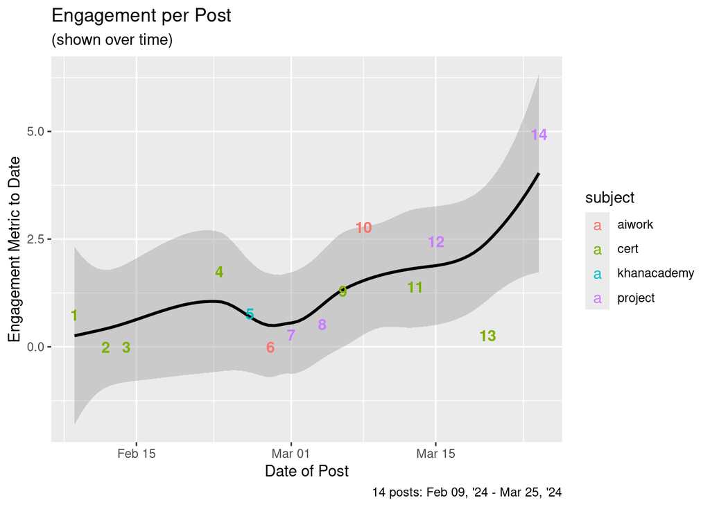

#### Engagement 5 Number Summary

```
## Minimum      Q1  Median      Q3 Maximum
##    0.00    0.26    0.76    1.75    4.94
```

(Engagement metric for all posts reported)

#### Views Time-Series

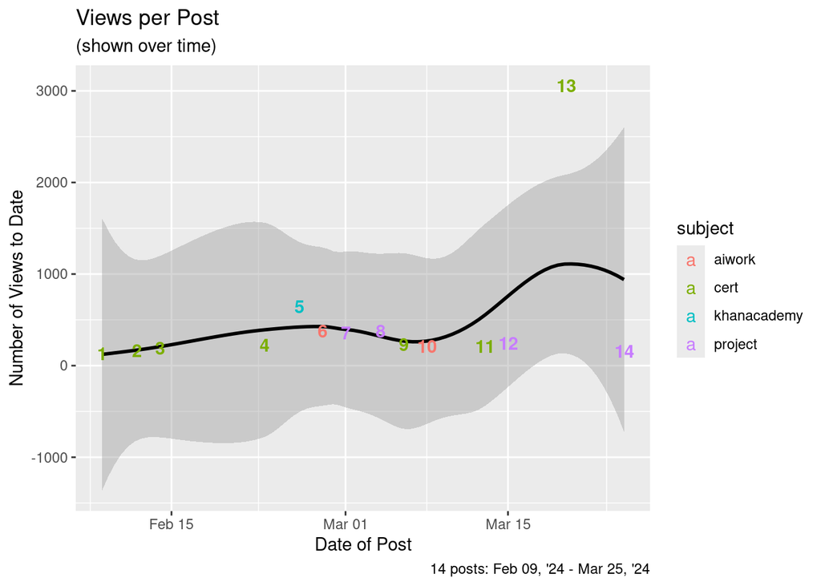

#### Views 5 Number Summary

```
## Minimum      Q1  Median      Q3 Maximum
##   134.0   193.0   229.5   380.0  3059.0
```

(Views for all posts reported)

#### Hashtags - Average Views

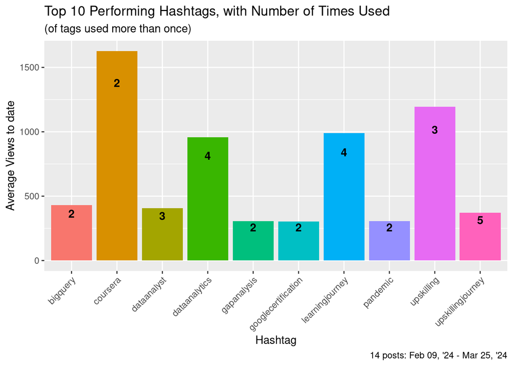

#### Post Day - Views

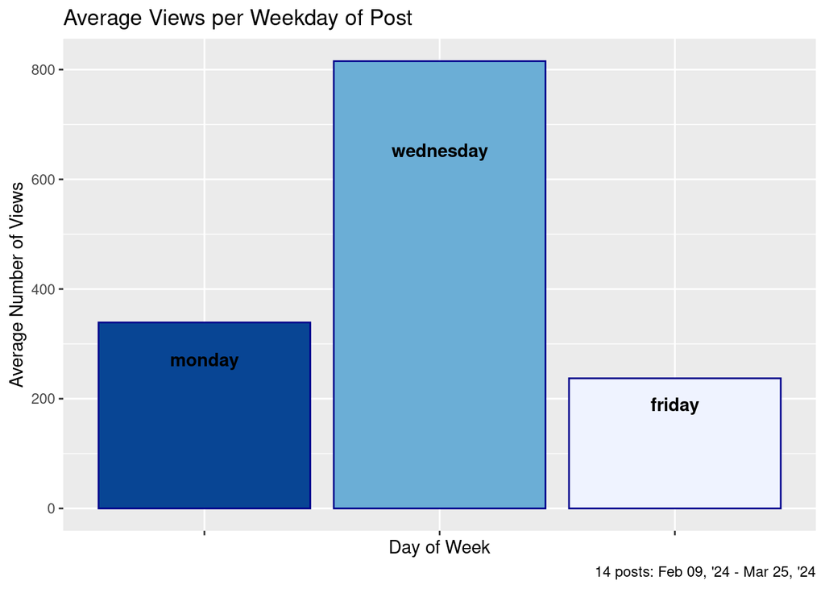

#### Image - Engagement

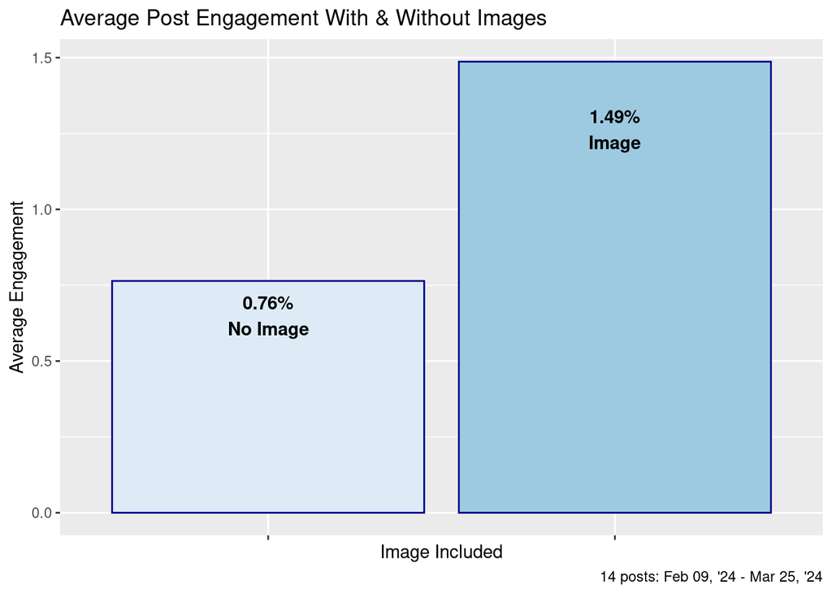

#### Link - Engagement

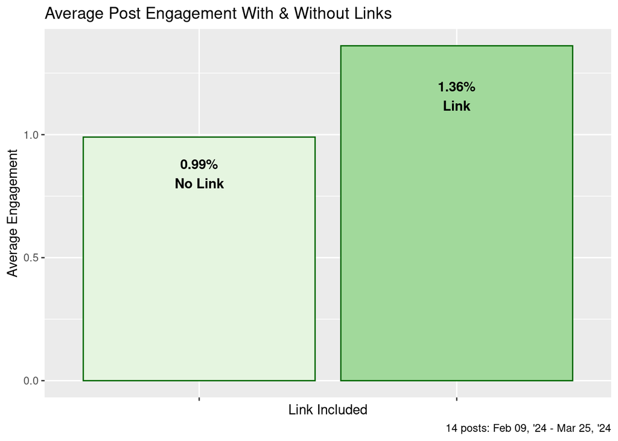

#### Emojis - Engagement

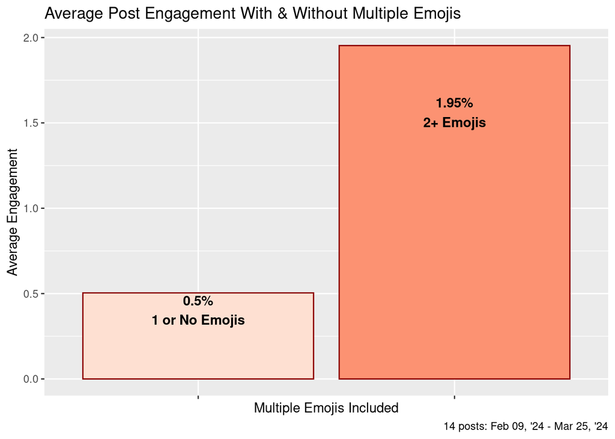

#### Cross Posted - Engagement

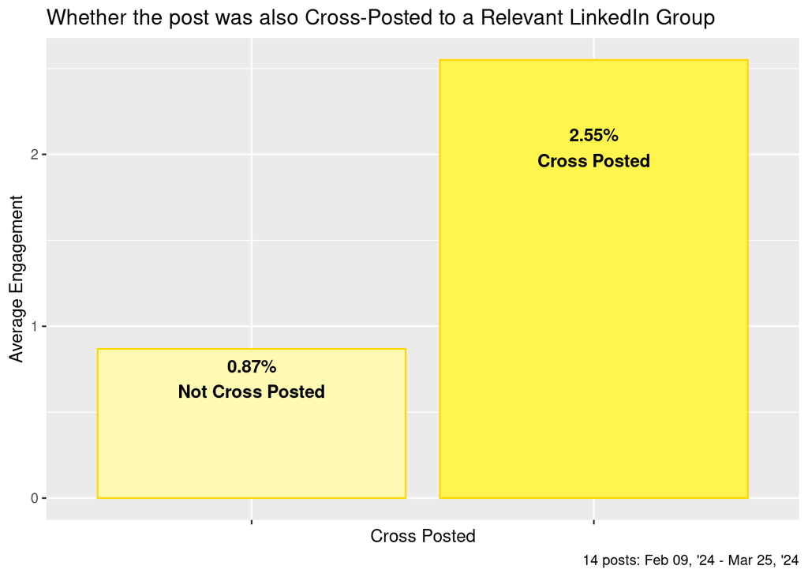

#### Several Metrics Scatter Plot

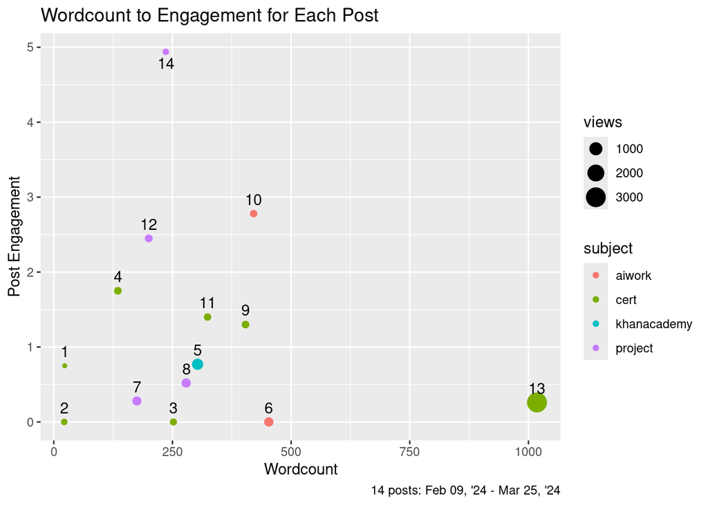

#### Wordcount 5 Number Summary

```
## Minimum      Q1  Median      Q3 Maximum
##    22.0   175.0   265.5   404.0  1018.0
```

#### Script Citations

R:

R Core Team (2021). R: A language and environment for statistical computing. R Foundation for Statistical Computing, Vienna, Austria. URL https://www.R-project.org/.

tidyverse:

Wickham H, Averick M, Bryan J, Chang W, McGowan LD, François R, Grolemund G, Hayes A, Henry L, Hester J, Kuhn M, Pedersen TL, Miller E, Bache SM, Müller K, Ooms J, Robinson D, Seidel DP, Spinu V, Takahashi K, Vaughan D, Wilke C, Woo K, Yutani H (2019). “Welcome to the tidyverse.” *Journal of Open Source Software*, *4*(43), 1686. doi: 10.21105/joss.01686 (URL: https://doi.org/10.21105/joss.01686).

janitor:

Sam Firke (2023). janitor: Simple Tools for Examining and Cleaning Dirty Data. R package version 2.2.0. https://CRAN.R-project.org/package=janitor

readr:

Hadley Wickham, Jim Hester and Jennifer Bryan (2024). readr: Read Rectangular Text Data. R package version 2.1.5. https://CRAN.R-project.org/package=readr

lubridate:

Garrett Grolemund, Hadley Wickham (2011). Dates and Times Made Easy with lubridate. Journal of Statistical Software, 40(3), 1-25. URL https://www.jstatsoft.org/v40/i03/.